# Cricket Results

## Subgroup Analysis

### Reduced form Effects

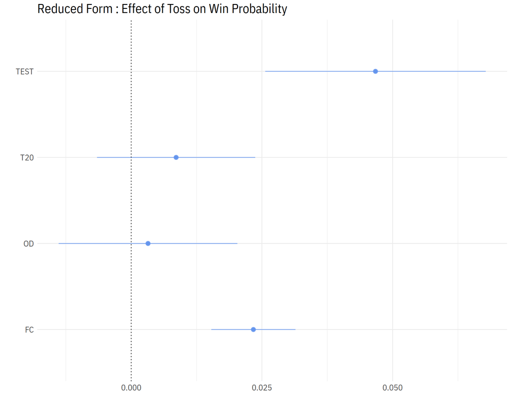

```r
reg_by_group(regsamp, type_of_match2,
    formula_lfe('wingame', 'wintoss', C = "mid")) %>% rbindlist %>%
  .[term == 'wintoss'] %>%
  coefplotter(., "Reduced Form : Effect of Toss on Win Probability")
```

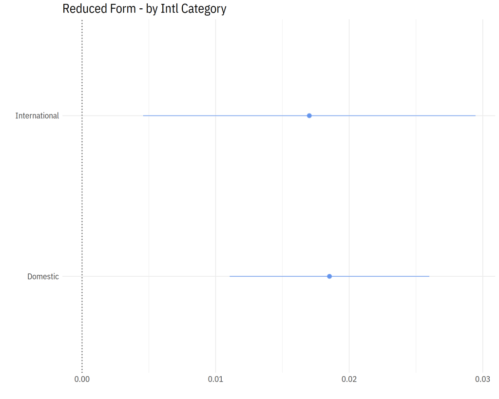

```r
reg_by_group(regsamp, di_type_of_match,
    formula_lfe('wingame', 'wintoss', C = "mid")) %>% rbindlist %>%
  .[term == "wintoss"] %>%
  coefplotter(., "Reduced Form - by Intl Category")
```

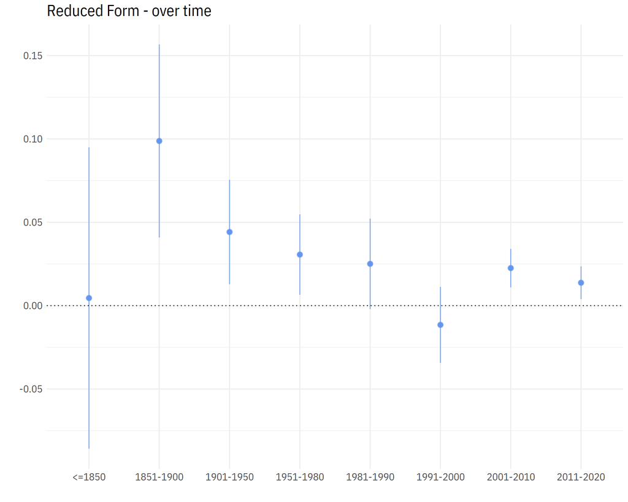

```r
reg_by_group(regsamp, time_unit,
    formula_lfe('wingame', 'wintoss', C = "mid")) %>% rbindlist %>%
  .[term == "wintoss"] %>%
  coefplotter(., "Reduced Form - over time") + coord_flip()
```

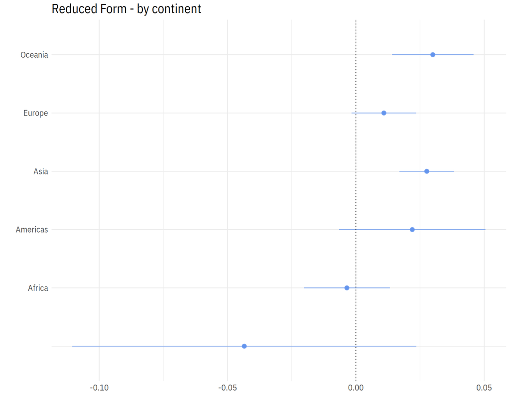

```r
reg_by_group(regsamp, continent,
    formula_lfe('wingame', 'wintoss', C = "mid")) %>% rbindlist %>%
  .[term == "wintoss"] %>%
  coefplotter(., "Reduced Form - by continent")
```

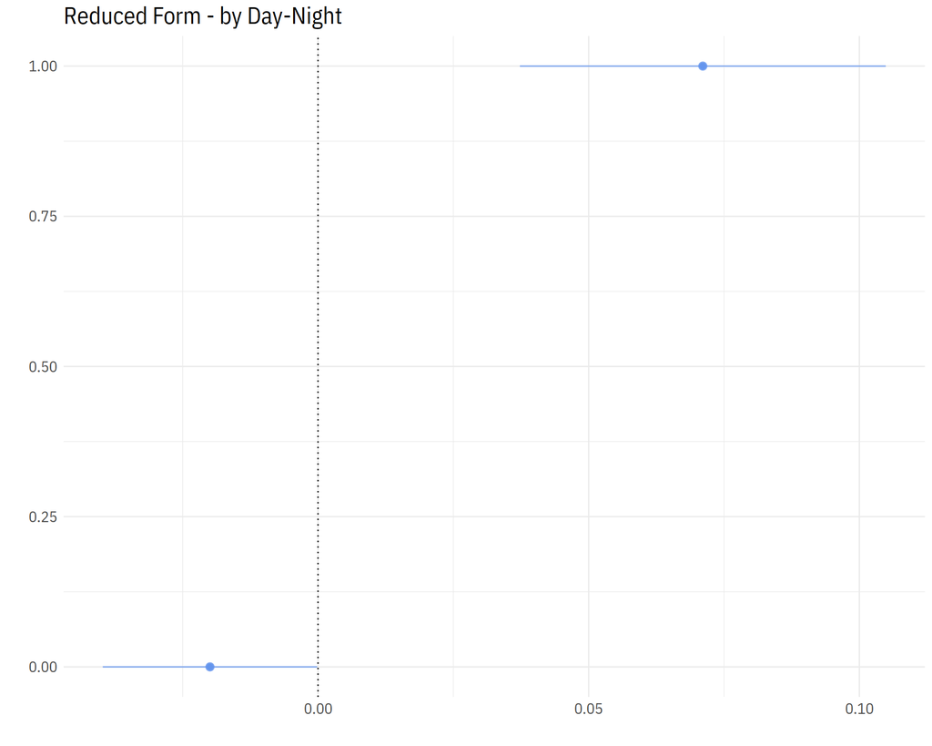

```r
regsamp[, dn := 1*(day_n_night == "day/night match")]

regsamp[type_of_match == "ODI"]  %>%
  reg_by_group(., dn,
    formula_lfe('wingame', 'wintoss', C = "mid")) %>% rbindlist %>%
  .[term == "wintoss"] %>%
  coefplotter(., "Reduced Form - by Day-Night")
```

### First stage

- History of team + ranking
- Micro-seasonality
- Team-FEs

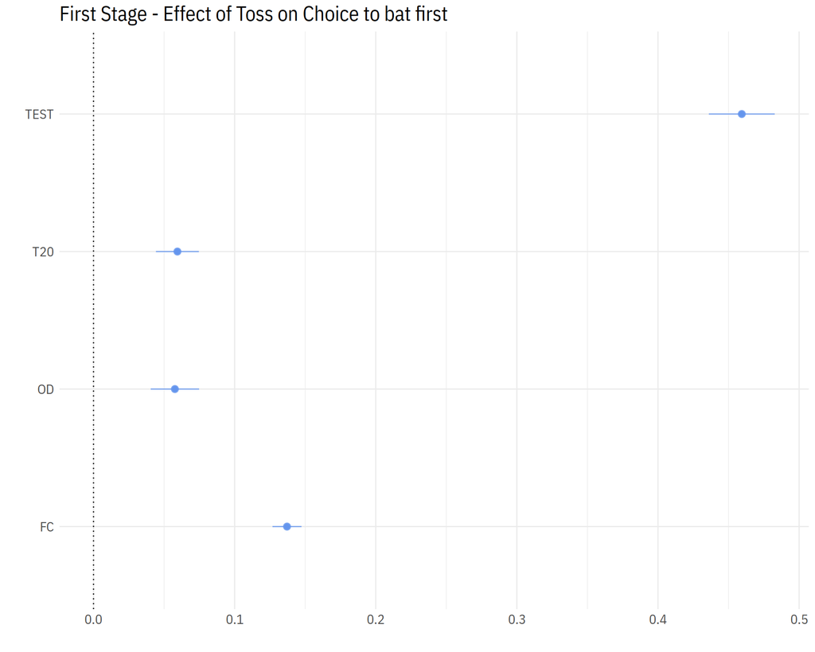

```r
reg_by_group(regsamp, type_of_match2,
    formula_lfe('bat_first', 'wintoss', C = "mid")) %>% rbindlist %>%
  .[term == "wintoss"] %>%
  coefplotter(., "First Stage - Effect of Toss on Choice to bat first")
```

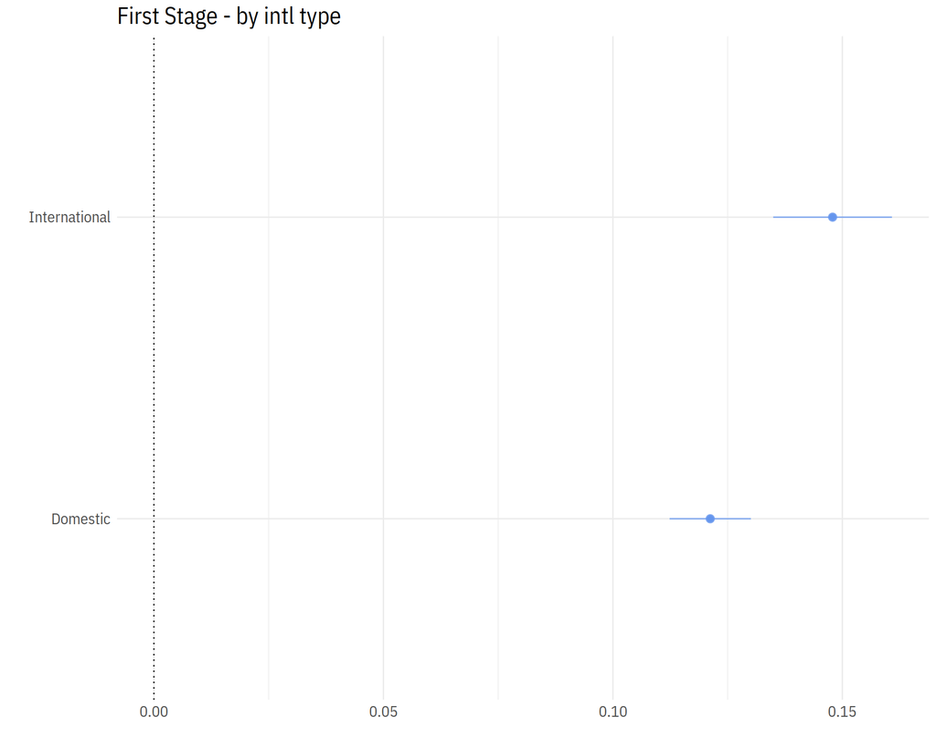

```r
reg_by_group(regsamp, di_type_of_match,
    formula_lfe('bat_first', 'wintoss', C = "mid")) %>% rbindlist %>%
  .[term == "wintoss"] %>%
  coefplotter(., "First Stage - by intl type")
```

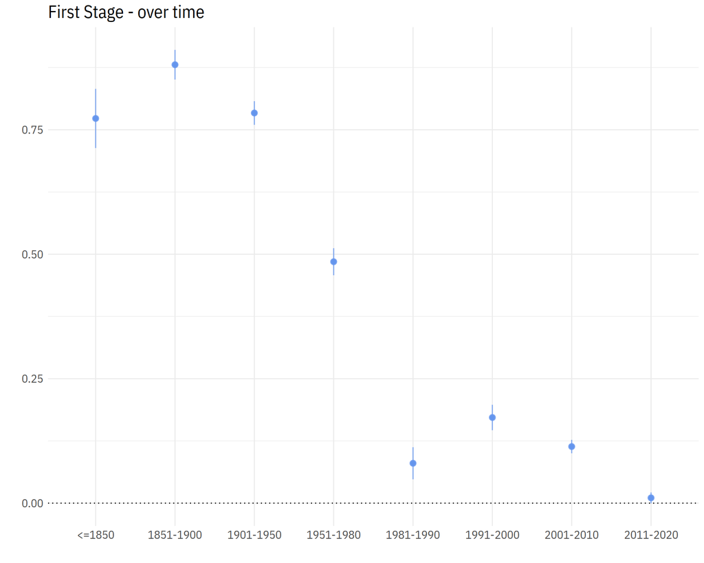

```r
reg_by_group(regsamp, time_unit,
    formula_lfe('bat_first', 'wintoss', C = "mid")) %>% rbindlist %>%
  .[term == "wintoss"] %>%
  coefplotter(., "First Stage - over time") + coord_flip()
```

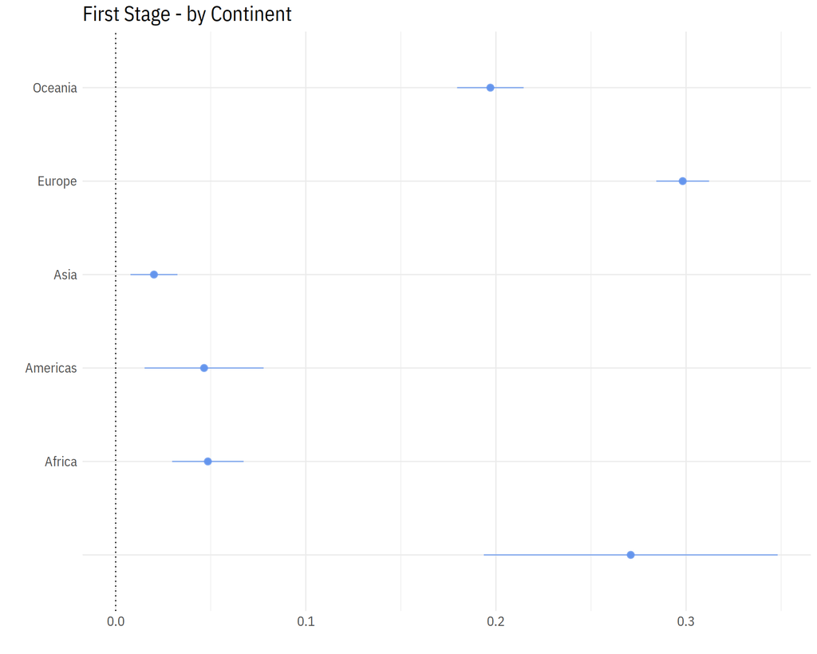

```r
reg_by_group(regsamp, continent,
    formula_lfe('bat_first', 'wintoss', C = "mid")) %>% rbindlist %>%
  .[term == "wintoss"] %>%
  coefplotter(., "First Stage - by Continent")
```

### IV by match type

- History of team

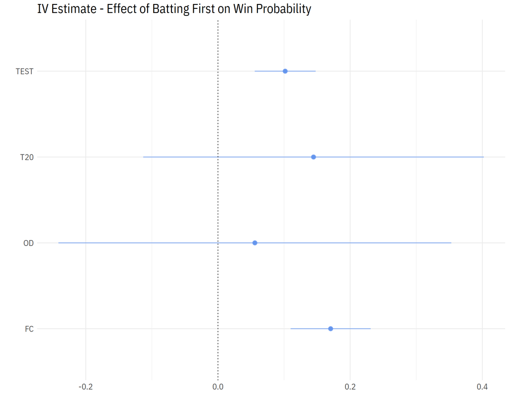

```r
# est = felm(wingame ~ 1 | 0 | (bat_first ~ wintoss) | mid , regsamp[type_of_match2 == "LISTA"])
# est
reg_by_group(regsamp, type_of_match2,
      as.formula("wingame ~ 1 | 0 | (bat_first ~ wintoss)| mid")) %>% rbindlist %>%
  .[term == "`bat_first(fit)`"] %>%
  coefplotter(., "IV Estimate - Effect of Batting First on Win Probability")
```

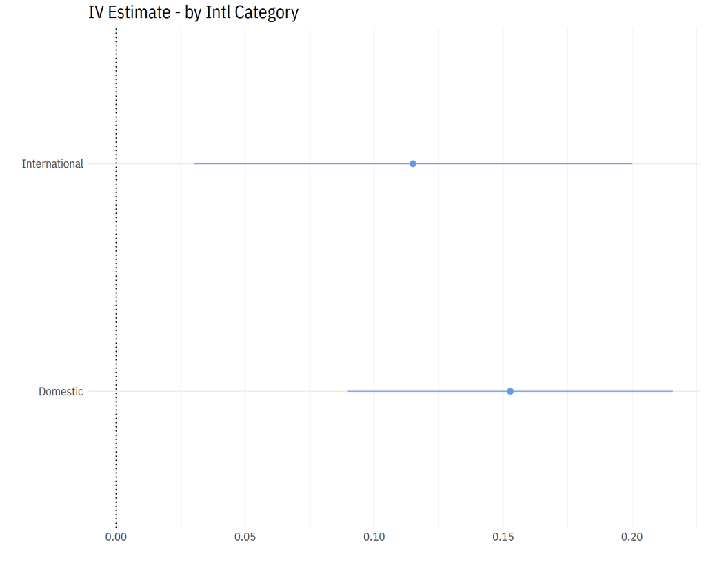

```r
reg_by_group(regsamp, di_type_of_match,
    as.formula('wingame ~ 1 | 0 | (bat_first ~ wintoss) | mid')) %>% rbindlist %>%
  .[term == "`bat_first(fit)`"] %>%
  coefplotter(., "IV Estimate - by Intl Category")
```

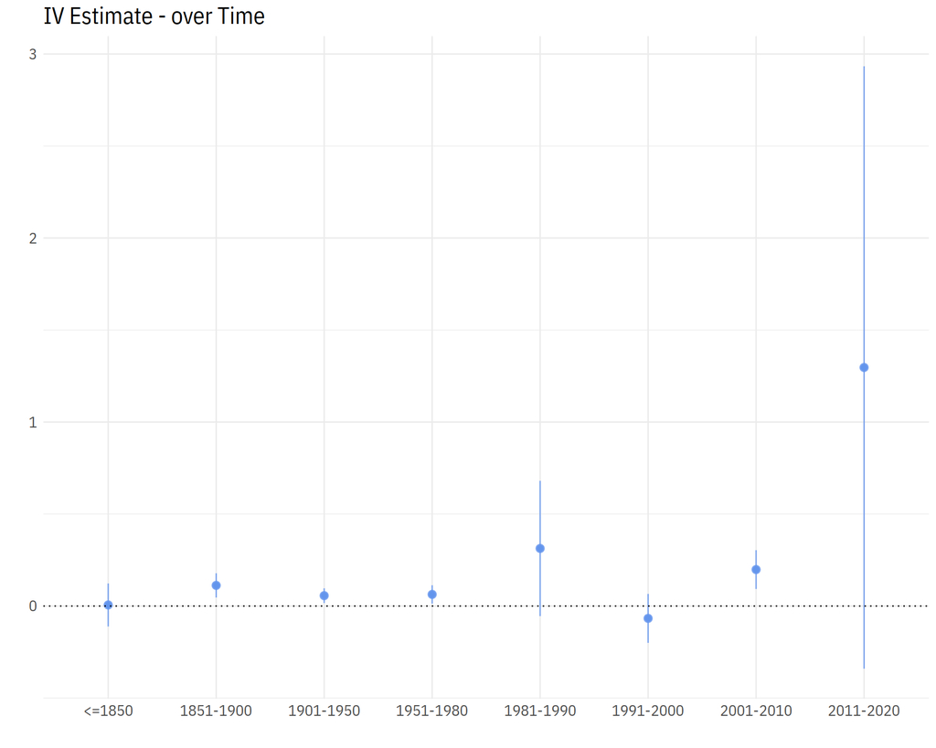

```r
reg_by_group(regsamp, time_unit,
    as.formula('wingame ~ 1 | 0 | (bat_first ~ wintoss) | mid')) %>% rbindlist %>%
  .[term == "`bat_first(fit)`"] %>%
  coefplotter(., "IV Estimate - over Time") + coord_flip()
```

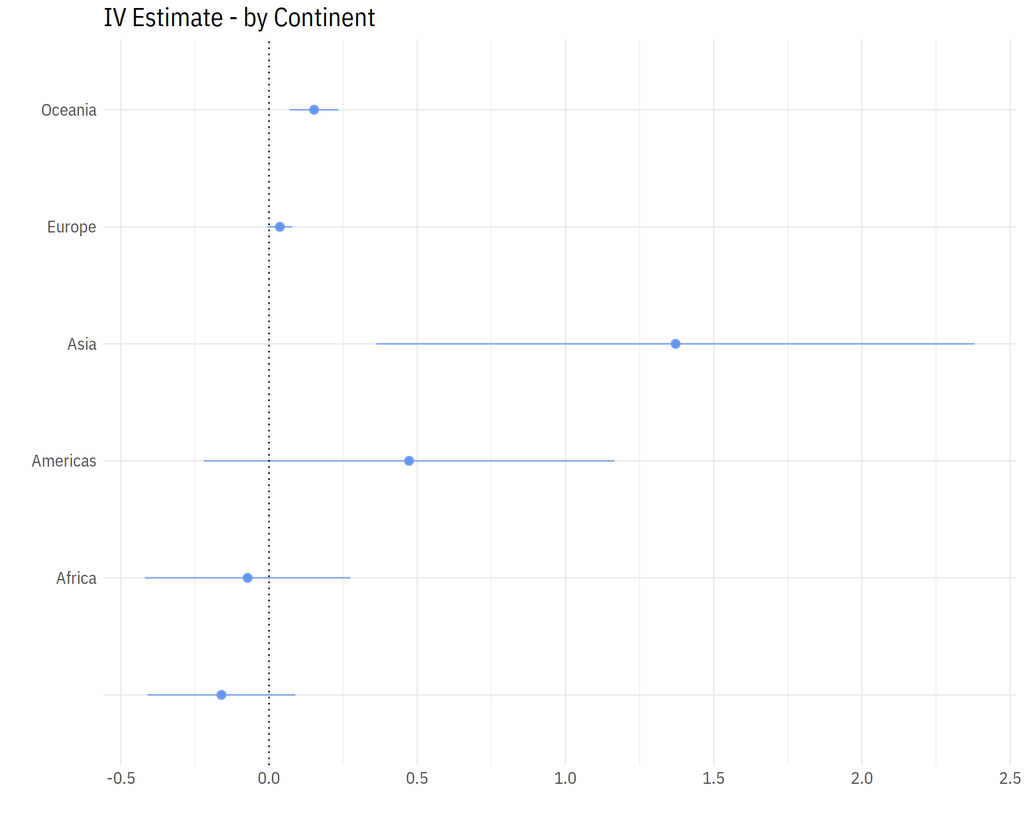

```r
reg_by_group(regsamp, continent,
    as.formula('wingame ~ 1 | 0 | (bat_first ~ wintoss) | mid')) %>% rbindlist %>%
  .[term == "`bat_first(fit)`"] %>%
  coefplotter(., "IV Estimate - by Continent")
```

## Characterising Compliers

$$P(D_1 > D_0) = E[D_1 - D_0] = E[D | Z = 1] - E[D | Z = 0]$$

```r
mu = regsamp[, mean(bat_first), wintoss][, V1]
always_takers = nrow(regsamp[wintoss != 1 & bat_first == 1]) / nrow(regsamp[wintoss != 1])
never_takers =  nrow(regsamp[wintoss == 1 & bat_first == 0]) / nrow(regsamp[wintoss == 1])
compliers = mu[2] - mu[1]


shares = data.frame(subpop = c('always takers', 'never takers', 'compliers'),
           share  = c(always_takers, never_takers, compliers[1]))
shares %>% kable()
```

| subpop | share |
| --- | --- |
| always takers | 0.4352 |
| never takers | 0.4352 |
| compliers | 0.1297 |

## $\kappa$ weighted summary statistics

The relative likelihood that a complier has $X = x$ is given by the ratio of the first stage for the subpopulation with $X = x$ to the overall first stage.

Target: mean for compliers

$$E[X | D_1 > D_0] = \frac{E[\kappa X]}{E[\kappa]}$$

where

$$\kappa = 1 - \frac{D (1-Z)}{P(Z = 0 | X)} - \frac{(1-D) Z}{P(Z = 1 | X)}$$

- $\approx$ 1 for identifiable compliers
- $\approx$ -1 for identifiable always takers
- $\approx$ -1 for identifiable never takers

Covars considered:

- underdog - lower ranked team in match
- day-night matches
- home team

```r
samp2 = regsamp[!is.na(rank) & !is.na(home_country)]
samp2[, lowrank := min(rank) , by = mid]
samp2[, underdog := ifelse(rank == lowrank, 1, 0)]
samp2[, dn := 1*(day_n_night == "day/night match")]
samp2[, home := 1*home_country]
samp2 = dummy_cols(samp2, select_columns = c('time_unit', 'continent')) %>%
  clean_names()


kappa_avg = function(xn, df = samp2) {
  x = as.matrix(df[, ..xn]); y = as.matrix(df$wingame)
  d = df$bat_first; z = df$wintoss
  ϕ = glm(z ~ x, family = binomial())$fitted.values
  κ = 1 - (d * (1-z))/(1-ϕ) - ((1-d) * z)/ϕ
  mean(κ * x) / mean(κ)
}

samp2 %>% glimpse
```

```
## Rows: 8,390
## Columns: 71
## $ match_id            <int> 602476, 602476, 567372, 567372, 602474, 602474, 5…
## $ mid                 <int> 18499, 18499, 18514, 18514, 18523, 18523, 18527, …
## $ date                <date> 2013-03-28, 2013-03-28, 2013-03-24, 2013-03-24, …
## $ date2               <chr> "03/28/2013", "03/28/2013", "03/24/2013", "03/24/…
## $ month               <int> 3, 3, 3, 3, 3, 3, 3, 3, 3, 3, 3, 3, 3, 3, 3, 3, 3…
## $ day                 <int> 28, 28, 24, 24, 23, 23, 22, 22, 22, 22, 21, 21, 2…
## $ year                <int> 2013, 2013, 2013, 2013, 2013, 2013, 2013, 2013, 2…
## $ rain                <lgl> NA, NA, NA, NA, NA, NA, NA, NA, NA, NA, NA, NA, N…
## $ diff_ranks          <int> 32, 32, 8, 8, 32, 32, 40, 40, 12, 12, 8, 8, NA, 8…
## $ bat_or_bowl         <int> 1, 1, 1, 1, 2, 2, 2, 2, 1, 1, 1, 1, 2, 2, 2, 2, 2…
## $ type_of_match       <chr> "ODI", "ODI", "ODI", "ODI", "ODI", "ODI", "TEST",…
## $ basic_type_of_match <chr> "LISTA/ODI", "LISTA/ODI", "LISTA/ODI", "LISTA/ODI…
## $ type_of_match2      <chr> "OD", "OD", "OD", "OD", "OD", "OD", "TEST", "TEST…
```

[output cut: 58 more lines]

```r
glue::glue("underdog share among compliers = {round(kappa_avg('underdog'), 3)}")
```

```
## underdog share among compliers = 0.524
```

```r
glue::glue("day-night share among compliers = {round(kappa_avg('dn'), 3)}")
```

```
## day-night share among compliers = 0.781
```

```r
glue::glue("home share among compliers = {round(kappa_avg('home'), 3)}")
```

```
## home share among compliers = 0.417
```

```r
glue::glue("DL among compliers = {round(kappa_avg('duckworth_lewis'), 3)}")
```

```
## DL among compliers = -0.035
```

```r
times = colnames(samp2) %>% str_subset("time_unit_")
time_kappa = times %>% map_dbl(kappa_avg)
cbind(times, time_kappa)
```

```
##      times                 time_kappa
## [1,] "time_unit_1850"      "0"
## [2,] "time_unit_1851_1900" "0"
## [3,] "time_unit_1901_1950" "0"
## [4,] "time_unit_1951_1980" "0.286051696596293"
## [5,] "time_unit_1981_1990" "-0.169466765745935"
## [6,] "time_unit_1991_2000" "0.236197025001066"
## [7,] "time_unit_2001_2010" "0.554438445790901"
## [8,] "time_unit_2011_2020" "0.0928218129797104"
```

## Local Average Response Function

CEF of $Y|X,D$ *for subpopulation of compliers*.

Target : $E[Y | X, D, D_1 > D_0]$.

Estimate using Kappa weighting.

```r
larf_fit = function(xn, df = samp2) {
  X = as.matrix(df[, ..xn]); y = as.matrix(df$wingame)
  d = df$bat_first; z = df$wintoss
  ϕ = glm(z ~ X, family = binomial())$fitted.values
  κ = 1 - (d * (1-z))/(1-ϕ) - ((1-d) * z)/ϕ
  Xw = cbind(1, X, d)
  larf <- solve(t(Xw) %*% diag(κ) %*% Xw ) %*% t(Xw) %*% diag(κ) %*% y
  return(larf)
}

larf_fit(c('underdog', 'dn', 'home'))
```

```
##              [,1]
##           0.66726
## underdog -0.32254
## dn        0.01555
## home     -0.05814
## d         0.02747
```

# Run Curves

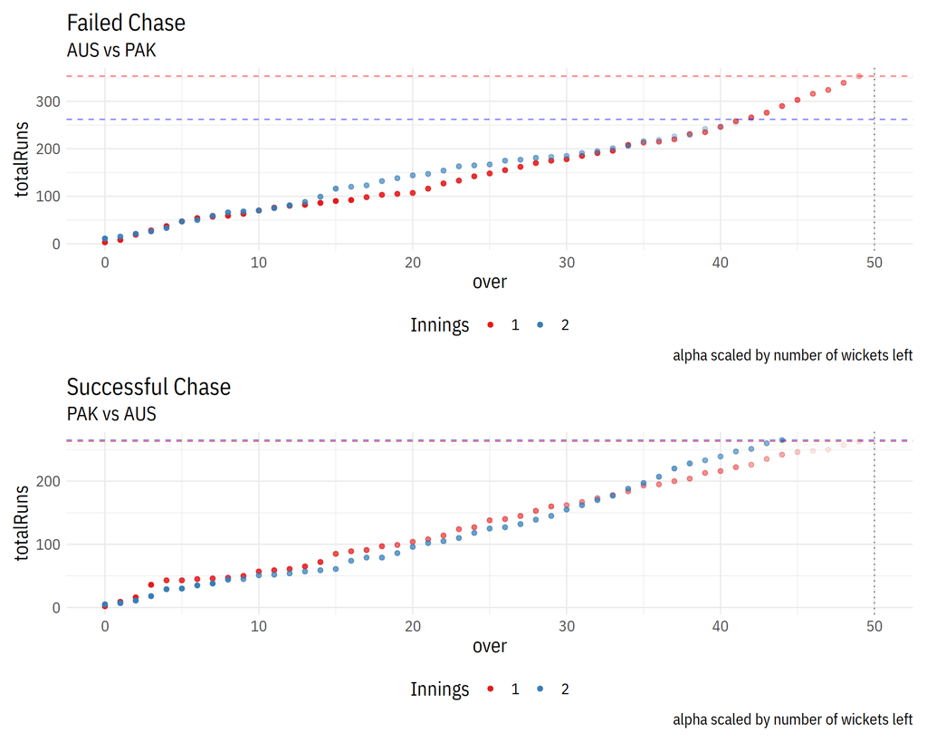

```r
library(patchwork)
df  = import(file.path(root, "tmp/overs_odi/overs/overs_1000891.json")) %>% setDT
df1 = import(file.path(root, "tmp/overs_odi/overs/overs_1000893.json")) %>% setDT
# %%
cum_run_curves = function(df){
  subt = paste(unique(df$teamShortName) , collapse = ' vs ')
  df[, remaining_wickets := 11 - totalWicket]
  # max run tallies
  totruns = df[, max(totalRuns), by = 'innings']
  # figure
  f = ggplot(df, aes(over, totalRuns, colour = as.factor(innings))) +
    geom_point(aes(alpha = remaining_wickets)) +
    geom_hline(yintercept = totruns[1, 2][[1]], colour = 'red', alpha = 0.5, linetype = 'dashed') +
    geom_hline(yintercept = totruns[2, 2][[1]], colour = 'blue' , alpha = 0.5, linetype = 'dashed') +
    geom_vline(xintercept = 50, alpha = 0.5, linetype = 'dotted') +
    scale_colour_brewer(palette = "Set1") +
    labs(subtitle = subt, caption = 'alpha scaled by number of wickets left',
      colour = 'Innings') + scale_alpha(guide = 'none')
  return(f)
}

p1 = cum_run_curves(df1) + ggtitle('Failed Chase')
p2 = cum_run_curves(df) + ggtitle('Successful Chase')

# %%
p = p1 / p2
p
```

```r
matchdata = fread(file.path(root, 'repos/cricket-stats/data/final_output.csv'))
ODIs = matchdata[type_of_match == "ODI"]
dl_matches = ODIs[duckworth_lewis == 1]
dl_ids = dl_matches[, match_id]
dl_id = dl_ids[[50]]
dl_matches[match_id == dl_id, outcome]
```

```
## [1] "South Africa won by 5 wickets (with 11 balls remaining) (D/L method)"
```

```r
# %%
match = import(file.path(root, glue::glue("tmp/overs_odi/overs/overs_{dl_id}.json"))) %>% setDT

match %>% glimpse
```

```
## Rows: 77
## Columns: 16
## $ maiden          <lgl> FALSE, FALSE, TRUE, FALSE, FALSE, FALSE, FALSE, FALSE…
## $ runs            <int> 6, 2, 0, 6, 6, 9, 11, 8, 1, 8, 9, 6, 3, 0, 9, 3, 7, 0…
## $ wickets         <int> 0, 0, 1, 0, 0, 0, 0, 0, 0, 0, 0, 0, 0, 1, 0, 0, 0, 1,…
## $ totalRuns       <int> 8, 2, 0, 40, 34, 28, 19, 66, 58, 57, 49, 84, 78, 75, …
## $ totalWicket     <int> 1, 1, 1, 1, 1, 1, 1, 1, 1, 1, 1, 2, 2, 2, 1, 3, 3, 3,…
## $ runRate         <dbl> 2.66, 1.00, 0.00, 5.71, 5.66, 5.60, 4.75, 6.00, 5.80,…
## $ requiredRunRate <dbl> 0, 0, 0, 0, 0, 0, 0, 0, 0, 0, 0, 0, 0, 0, 0, 0, 0, 0,…
## $ batsmen         <list> [<data.frame[2 x 4]>, <data.frame[2 x 4]>, <data.fra…
## $ bowlers         <list> [<data.frame[2 x 6]>, <data.frame[2 x 6]>, <data.fra…
## $ teamShortName   <chr> "NZ", "NZ", "NZ", "NZ", "NZ", "NZ", "NZ", "NZ", "NZ",…
## $ remainingOvers  <int> 0, 0, 0, 0, 0, 0, 0, 0, 0, 0, 0, 0, 0, 0, 0, 0, 0, 0,…
## $ remainingBalls  <int> 0, 0, 0, 0, 0, 0, 0, 0, 0, 0, 0, 0, 0, 0, 0, 0, 0, 0,…
## $ remainingRuns   <int> 0, 0, 0, 0, 0, 0, 0, 0, 0, 0, 0, 0, 0, 0, 0, 0, 0, 0,…
## $ match           <chr> "224227", "224227", "224227", "224227", "224227", "22…
## $ innings         <int> 1, 1, 1, 1, 1, 1, 1, 1, 1, 1, 1, 1, 1, 1, 1, 1, 1, 1,…
## $ over            <int> 2, 1, 0, 6, 5, 4, 3, 10, 9, 8, 7, 14, 13, 12, 11, 18,…
```

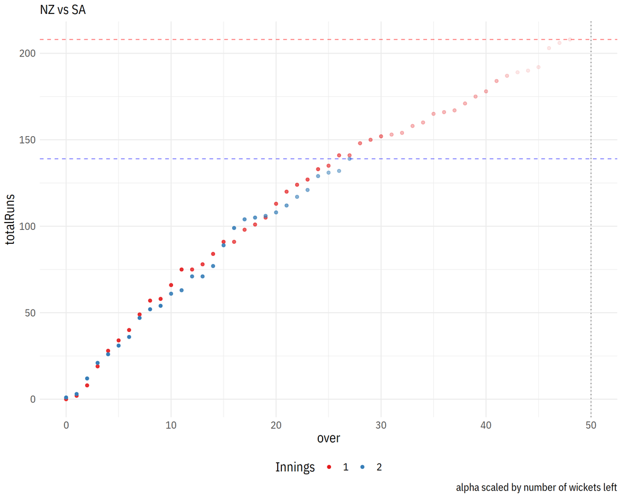

```r
cum_run_curves(match)
```